# 543 assignment 1

#### Data Source

The World Happiness Report is a landmark survey of the state of global happiness . The report continues to gain global recognition as governments, organizations and civil society increasingly use happiness indicators to inform their policy-making decisions. Leading experts across fields – economics, psychology, survey analysis, national statistics, health, public policy and more – describe how measurements of well-being can be used effectively to assess the progress of nations. The reports review the state of happiness in the world today and show how the new science of happiness explains personal and national variations in happiness.

[figure not shown]

```r
Testdata = read.csv(load(file=url(link)))
```

[output not shown]

#### Information of Variables

This dataset contains data such as the various countries selected, their rigion, their final ladder score, log of GDP per capita, index of social support, healthy life expectancy, index of freedom of making life choices, index of generosity, index of perception of corruption, respective populations in the year 2019 and 2020, total COVID-19 deaths in each of these countries, the median age in the corresponding countries considered, whether it is an island or not, index of exposure to COVID-19 infections in other countries as of march 31, whether a female head of government or not and so on.

```r
# Get some information on the data
head(WHRData2021)
```

|  | Country.name | Regional.indicator | Ladder.score | Standard.error.of.ladder.score | upperwhisker | lowerwhisker | Logged.GDP.per.capita | Social.support | Healthy.life.expectancy | Freedom.to.make.life.choices | Generosity | Perceptions.of.corruption | Ladder.score.in.Dystopia | Log.GDP.per.capita | Index.of.Social.support | Index.of.Healthy.life.expectancy | Index.of.Freedom.to.make.life.choices | Index.of.Generosity | Index.of.Perceptions.of.corruption | Dystopia...residual | Population.2020 | Population.2019 | COVID.19.deaths.per.100.000.population.in.2020 | Median.age | Island | Index.of.exposure.to.COVID.19..infections.in.other.countries.as.of.March.31 | Log.of.average.distance.to.SARS.countries | WHO.Western.Pacific.Region | Female.head.of.government | … |
| --- | --- | --- | --- | --- | --- | --- | --- | --- | --- | --- | --- | --- | --- | --- | --- | --- | --- | --- | --- | --- | --- | --- | --- | --- | --- | --- | --- | --- | --- | --- |
| 1 | Finland | Western Europe | 7.842 | 0.032 | 7.904 | 7.780 | 10.775 | 0.954 | 72.0 | 0.949 | -0.098 | 0.186 | 2.43 | 1.446 | 1.106 | 0.741 | 0.691 | 0.124 | 0.481 | 3.253 | 5540718 | 5520314 | 10.125 | 42.8 | 0 | 2.225 | 8.927 | 0 | 1 | … |
| 2 | Denmark | Western Europe | 7.620 | 0.035 | 7.687 | 7.552 | 10.933 | 0.954 | 72.7 | 0.946 | 0.030 | 0.179 | 2.43 | 1.502 | 1.108 | 0.763 | 0.686 | 0.208 | 0.485 | 2.868 | 5792203 | 5818553 | 22.409 | 42.3 | 0 | 3.953 | 9.006 | 0 | 1 | … |
| 3 | Switzerland | Western Europe | 7.571 | 0.036 | 7.643 | 7.500 | 11.117 | 0.942 | 74.4 | 0.919 | 0.025 | 0.292 | 2.43 | 1.566 | 1.079 | 0.816 | 0.653 | 0.204 | 0.413 | 2.839 | 8654618 | 8574832 | 88.334 | 43.1 | 0 | 5.584 | 9.078 | 0 | 0 | … |
| 4 | Iceland | Western Europe | 7.554 | 0.059 | 7.670 | 7.438 | 10.878 | 0.983 | 73.0 | 0.955 | 0.160 | 0.673 | 2.43 | 1.482 | 1.172 | 0.772 | 0.698 | 0.293 | 0.170 | 2.967 | 341250 | 361313 | 8.498 | 37.3 | 1 | 1.649 | 9.070 | 0 | 1 | … |
| 5 | Netherlands | Western Europe | 7.464 | 0.027 | 7.518 | 7.410 | 10.932 | 0.942 | 72.4 | 0.913 | 0.175 | 0.338 | 2.43 | 1.501 | 1.079 | 0.753 | 0.647 | 0.302 | 0.384 | 2.798 | 17134873 | 17332850 | 67.260 | 43.2 | 0 | 5.574 | 9.060 | 0 | 0 | … |
| 6 | Norway | Western Europe | 7.392 | 0.035 | 7.462 | 7.323 | 11.053 | 0.954 | 73.3 | 0.960 | 0.093 | 0.270 | 2.43 | 1.543 | 1.108 | 0.782 | 0.703 | 0.249 | 0.427 | 2.580 | 5421242 | 5347896 | 8.042 | 39.7 | 0 | 2.676 | 8.993 | 0 | 1 | … |

```r
# summary(WHRData2021)
```

The variable of ladder score is the happiness level for each country. The columns following the happiness score estimate the extent to which each of six factors – economic production, social support, life expectancy, freedom, absence of corruption, and generosity – contribute to making life evaluations higher in each country than they are in Dystopia, a hypothetical country that has values equal to the world’s lowest national averages for each of the six factors.

#### Data exploration

```r
# how many unique countries
length(unique(WHRData2021$Country.name))
```

There are 148 countries in this dataset.

```r
Countries=aggregate(data=WHRData2021,
                         Country.name~Regional.indicator,
                         FUN=length)
Countries
```

| Regional.indicator | Country.name |
| --- | --- |
| Central and Eastern Europe | 17 |
| Commonwealth of Independent States | 12 |
| East Asia | 6 |
| Latin America and Caribbean | 20 |
| Middle East and North Africa | 17 |
| North America and ANZ | 4 |
| South Asia | 7 |
| Southeast Asia | 9 |
| Sub-Saharan Africa | 35 |
| Western Europe | 21 |

We now can see the number of countries for each region.

#### 1. [Practice] Picture of Country Population

##### 1.1 Get the population number (country level)

```r
# get population data
pop2020 = cbind(WHRData2021[,1:2],WHRData2021[,21:22])

# delete rows with na values: None
pop2020 = pop2020[complete.cases(pop2020),]
```

##### 1.2 Order by 2020 population to get information of countries with most populations.

```r
# order by population in 2020 and show the first 20 countries
pop2020=pop2020[order(-pop2020$Population.2020),]
head(pop2020,20)
```

|  | Country.name | Regional.indicator | Population.2020 | Population.2019 |
| --- | --- | --- | --- | --- |
| 84 | China | East Asia | 1439323774 | 1397715000 |
| 138 | India | South Asia | 1380004385 | 1366417754 |
| 19 | United States | North America and ANZ | 331002647 | 328239523 |
| 82 | Indonesia | Southeast Asia | 273523621 | 270625568 |
| 105 | Pakistan | South Asia | 220892331 | 216565318 |
| 35 | Brazil | Latin America and Caribbean | 212559409 | 211049527 |
| 116 | Nigeria | Sub-Saharan Africa | 206139587 | 200963599 |
| 101 | Bangladesh | South Asia | 164689383 | 163046161 |
| 76 | Russia | Commonwealth of Independent States | 145934460 | 144373535 |
| 36 | Mexico | Latin America and Caribbean | 128932753 | 127575529 |

[output cut: 10 more lines]

The top 5 countires are China, India, United States, Indonesia and Pakistan.

##### 1.3 Calculate the cumulated number and percentages.

```r
pop2020$Population.2020 = pop2020$Population.2020/1000000
pop2020$Population.2019 = pop2020$Population.2019/1000000
pop2020$Percent2020=pop2020$Population.2020/sum(pop2020$Population.2020)
pop2020$PercentCum=cumsum(pop2020$Percent)
pop2020$Pop2020Cum=cumsum(as.numeric(pop2020$Population.2020))
pop2020$Pop.change = pop2020$Population.2020 - pop2020$Population.2019
pop2020$Pop.change.rate = pop2020$Pop.change/pop2020$Population.2019
# see some:
head(pop2020,10)
```

|  | Country.name | Regional.indicator | Population.2020 | Population.2019 | Percent2020 | PercentCum | Pop2020Cum | Pop.change | Pop.change.rate |
| --- | --- | --- | --- | --- | --- | --- | --- | --- | --- |
| 84 | China | East Asia | 1439.3238 | 1397.7150 | 0.19199624 | 0.1919962 | 1439.324 | 41.608774 | 0.029769140 |
| 138 | India | South Asia | 1380.0044 | 1366.4178 | 0.18408343 | 0.3760797 | 2819.328 | 13.586631 | 0.009943248 |
| 19 | United States | North America and ANZ | 331.0026 | 328.2395 | 0.04415356 | 0.4202332 | 3150.331 | 2.763124 | 0.008418011 |
| 82 | Indonesia | Southeast Asia | 273.5236 | 270.6256 | 0.03648624 | 0.4567195 | 3423.854 | 2.898053 | 0.010708718 |
| 105 | Pakistan | South Asia | 220.8923 | 216.5653 | 0.02946557 | 0.4861850 | 3644.747 | 4.327013 | 0.019980175 |
| 35 | Brazil | Latin America and Caribbean | 212.5594 | 211.0495 | 0.02835401 | 0.5145390 | 3857.306 | 1.509882 | 0.007154160 |
| 116 | Nigeria | Sub-Saharan Africa | 206.1396 | 200.9636 | 0.02749765 | 0.5420367 | 4063.446 | 5.175988 | 0.025755848 |
| 101 | Bangladesh | South Asia | 164.6894 | 163.0462 | 0.02196847 | 0.5640052 | 4228.135 | 1.643222 | 0.010078262 |
| 76 | Russia | Commonwealth of Independent States | 145.9345 | 144.3735 | 0.01946669 | 0.5834719 | 4374.070 | 1.560925 | 0.010811711 |
| 36 | Mexico | Latin America and Caribbean | 128.9328 | 127.5755 | 0.01719877 | 0.6006706 | 4503.002 | 1.357224 | 0.010638592 |

##### 1.4 Get the list of countries that make up 80% and 50% of the world’s population.

```r
countries80 = pop2020[pop2020$PercentCum<0.8,"Country.name"]
length(countries80)
```

```
[1] 30
```

```r
countries50 = pop2020[pop2020$PercentCum<0.5,"Country.name"]
length(countries50)
```

```
[1] 5
```

```r
countries_80= pop2020[pop2020$PercentCum<0.8,]
```

30 countries (20.3%) in this dataset make up 80% of the population and 5 countries (3.4%) make up for 50%.

##### 1.5 Plot the picture

```r
library(ggplot2)

base1=ggplot(data=countries_80,
             aes(x=Country.name, Population.2020, fill=Pop.change.rate)) + theme_classic() + scale_x_discrete(limits=countries_80$Country.name) + theme(axis.text.y = element_text(face=ifelse(countries_80$Country.name%in%countries50,"bold","plain"))) + xlab("Country") + ylab("Population[millions]")
```

```
Vectorized input to `element_text()` is not officially supported.
Results may be unexpected or may change in future versions of ggplot2.
```

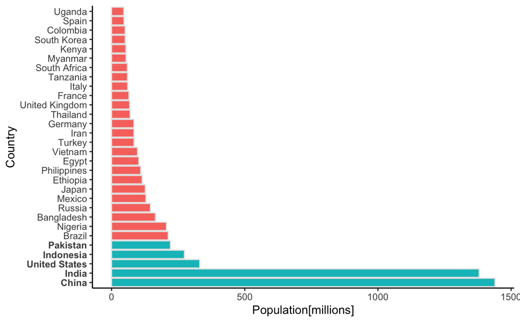

```r
bar1=base1 + geom_bar(stat = "identity",color='grey90',
                      aes(fill=PercentCum<0.5),
                      show.legend = F) +  coord_flip()
bar1
```

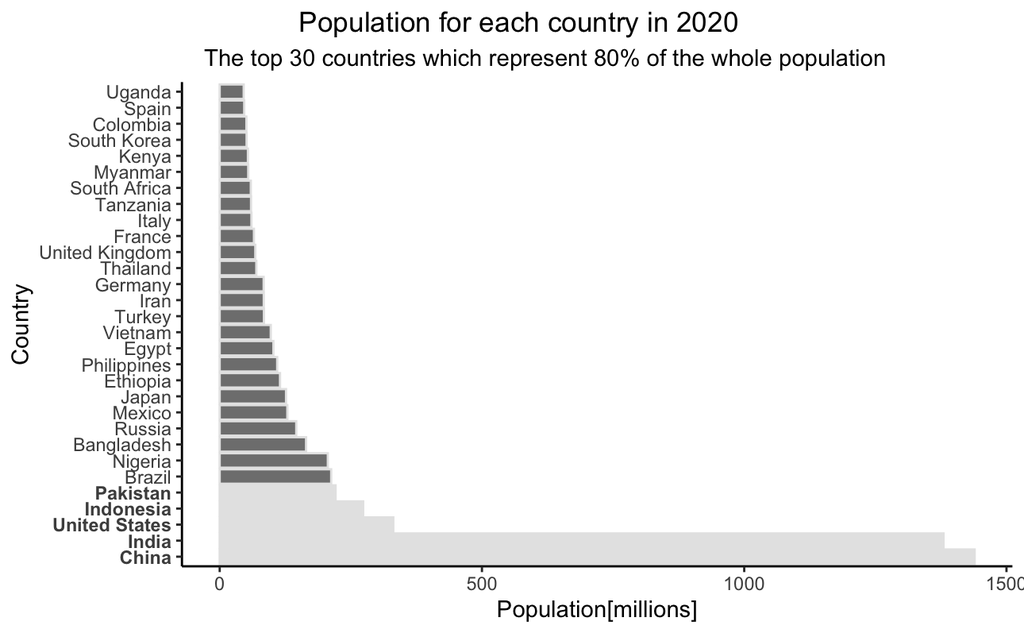

```r
# Add the title and subtitle
bar2 = bar1 + scale_fill_manual(values=c(NA,"grey90")) + labs(title="Population for each country in 2020", subtitle="The top 30 countries which represent 80% of the whole population")+ theme(plot.title = element_text(hjust = 0.3), plot.subtitle = element_text(hjust = 0.15))
bar2
```

```r
library(ggQC)
base2=ggplot(data=countries_80,
             aes(x=Country.name,y=Population.2020)) + theme_classic()+ scale_x_discrete(limits=countries_80$Country.name)
pare1=base2 + stat_pareto() + theme(axis.text.x = element_text(angle = 30, hjust = 1,face=ifelse(countries_80$Country.name%in%countries50,"bold","plain")))
```

```
Vectorized input to `element_text()` is not officially supported.
Results may be unexpected or may change in future versions of ggplot2.
```

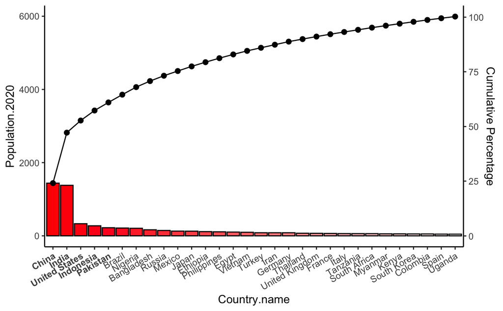

```r
pare1
```

#### 2. Average Life Expectancy for each reagion

*This is the picture for assignment 1.*

##### 2.1 Aggregate the number by region and order it by the result

```r
# aggregate 'Healthy.life.expectancy' by 'Regional.indicator'
LifeExp_countries=aggregate(data=WHRData2021,
                         Healthy.life.expectancy~Regional.indicator,
                         FUN=mean)
# get standard error
LifeExp_sd=aggregate(data=WHRData2021,
                         Healthy.life.expectancy~Regional.indicator,
                         FUN=sd)
# merge two dataframe
LifeExp_countries = merge(LifeExp_countries,LifeExp_sd, by='Regional.indicator')
# rename the columns
colnames(LifeExp_countries) = c('Region', 'LifeExp','LifeExpStd')
# order by the average life expectancy
LifeExp_countries=LifeExp_countries[order(-LifeExp_countries$LifeExp),]
```

Western Europe has the highest average life expectancy.

##### 2.2 Plot the pictur

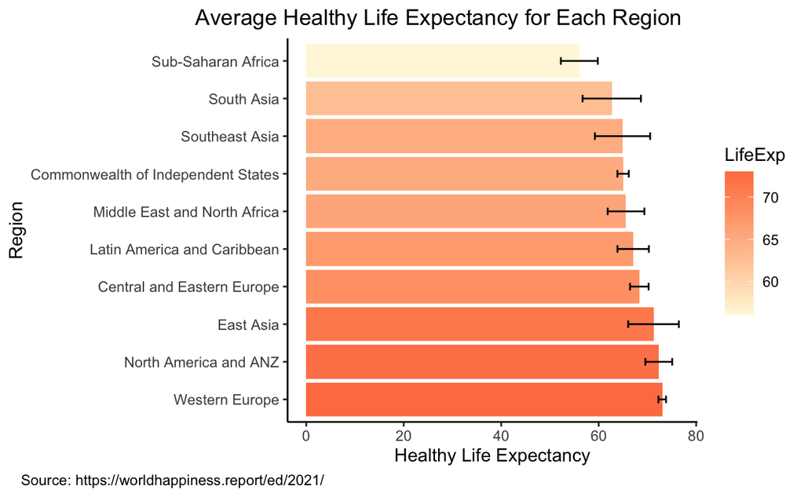

```r
TitleText = "Average Healthy Life Expectancy for Each Region"
CaptionText = "Source: https://worldhappiness.report/ed/2021/"

base3 = ggplot(data=LifeExp_countries, aes(x=Region, y=LifeExp, fill=LifeExp))+ theme_classic()+scale_fill_gradient(low = "cornsilk", high = "coral") + xlab("Region") + ylab("Healthy Life Expectancy") + scale_x_discrete(limits=LifeExp_countries$Region)

# add errobar which shows the within-group variability
bar3 = base3 + geom_bar(stat="identity", position = "dodge")+ geom_errorbar(aes(ymax = LifeExp+LifeExpStd, ymin = LifeExp-LifeExpStd), position = position_dodge(0.8),width=0.2)


bar4 = bar3 + coord_flip() + labs(title=TitleText, caption=CaptionText) + theme(plot.title = element_text(hjust = 1.2), plot.caption = element_text(hjust = -2.5))

#+ theme(axis.text.x = element_text(angle = 30, hjust = 1))
bar4
```

Several findings:  
a) Western Europe has both the highest average life expectancy and the least in-group variance.  
b) Sub-Saharan Africa has the lowest average life expectancy.  
c) Regions in Asia tend to have higher variance.